# Comparative Equity Analysis: Ford Motor Company (F) vs. General Motors Company (GM)

## Executive Summary

### Key Metrics Comparison

| Metric | F | GM |
| --- | --- | --- |
| Market Cap (USD Bn) | 39.5 | 43.5 |
| Trailing P/E | 6.80 | 7.06 |
| Forward P/E | 5.67 | 4.26 |
| Price/Sales | 0.21 | 0.23 |
| Price/Book | 0.88 | 0.69 |
| EV/EBITDA | 15.61 | 8.78 |
| Dividend Yield (%) | 7.39 | 1.02 |
| Payout Ratio | 0.53 | 0.08 |
| Revenue Growth (YoY) | 4.9% | 2.3% |
| Gross Margin (%) | 8.4 | 12.0 |
| EBITDA Margin (%) | 6.0 | 9.8 |
| Operating Margin (%) | 1.9 | 7.6 |
| Debt/Equity | 359 | 200 |
| Current Ratio | 1.17 | 1.21 |
| Free Cash Flow (USD Mn) | 859 | 1,262 |
| Analyst Recommendation | Hold | Buy |

### Comparative Analysis

Both Ford and GM operate in the highly competitive auto manufacturing sector, but their financial and behavioral profiles diverge in meaningful ways. GM demonstrates a clear edge in profitability, with stronger gross, EBITDA, and operating margins, suggesting more efficient operations and better cost control. While Ford’s revenue growth outpaces GM’s, the latter’s earnings growth rate is notably higher, indicating more effective conversion of sales into profits. Ford’s higher dividend yield and payout ratio may appeal to income-focused investors, but GM’s lower payout and higher free cash flow suggest a more sustainable capital allocation strategy. On the balance sheet, GM maintains a less leveraged capital structure, which could provide greater resilience in downturns. Analyst sentiment is more favorable for GM, with a consensus ‘Buy’ rating versus Ford’s ‘Hold’, and GM enjoys higher institutional ownership, reflecting greater confidence from large investors. Management commentary from GM has been forward-looking and focused on innovation and cost discipline, while Ford’s tone has been more cautious, emphasizing operational challenges and market uncertainties. Insider activity is limited for both, but analyst revisions have trended more positively for GM, reinforcing the behavioral edge.

## Ford Motor Company (F) Analysis

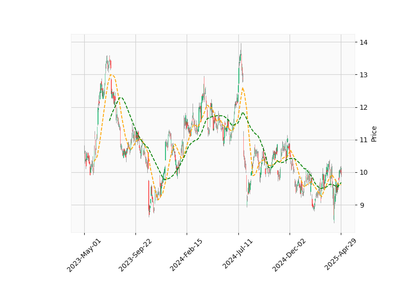

F Chart

Ford’s business model is anchored in a broad portfolio spanning trucks, SUVs, commercial vehicles, and luxury offerings under the Lincoln brand, with a growing emphasis on electrification and digital services. The company benefits from a vast dealer network and a significant presence in commercial and government fleet sales, providing some insulation from consumer cyclicality. Financially, Ford’s margins lag sector peers, reflecting ongoing cost pressures and heavy investment in EV and digital transformation initiatives. While revenue growth has been respectable, profitability remains constrained by high leverage and modest free cash flow generation. The balance sheet is stretched, with a high debt-to-equity ratio and only moderate liquidity, raising questions about flexibility in a downturn. Ford’s capital allocation favors dividends, offering a yield well above the sector average, but this comes at the expense of reinvestment and may not be sustainable if cash flows falter. On the technical front, Ford’s price action is range-bound, with moving averages converging and momentum indicators neutral, suggesting indecision among market participants. Strengths include brand recognition, scale, and a robust commercial business; weaknesses are margin compression and leverage. Opportunities lie in successful EV execution and digital monetization, while threats include macro headwinds, competitive intensity, and execution risk. Valuation is undemanding, but this reflects market skepticism about near-term earnings power. The base case outlook is for continued operational grind with limited upside unless margin improvement materializes; a bullish scenario would require a step-change in EV profitability or cost discipline, while a bearish case could see further multiple compression if leverage concerns intensify.

## General Motors Company (GM) Analysis

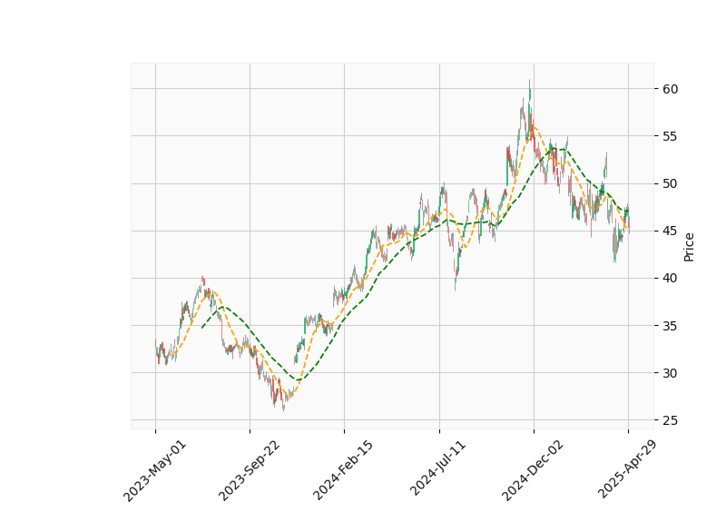

GM Chart

GM operates a diversified global platform with strong brands across multiple segments, including Buick, Cadillac, Chevrolet, and GMC, and is aggressively pursuing software-enabled services and electrification. The company has demonstrated superior margin performance, reflecting disciplined cost management and a more favorable product mix. GM’s free cash flow is robust, supporting ongoing investment in innovation while maintaining a conservative payout policy. The balance sheet is healthier than Ford’s, with lower leverage and higher liquidity, providing strategic flexibility. Analyst sentiment is constructive, and management has articulated a clear vision for growth in EVs, autonomous driving, and digital services, which is resonating with institutional investors. Technically, GM’s shares are stabilizing after a pullback, with trend indicators suggesting a potential inflection point. Strengths include operational efficiency, brand depth, and a scalable technology roadmap; weaknesses are exposure to cyclical demand and execution risk in new ventures. Opportunities are significant in EVs, software, and international expansion, while threats include regulatory shifts, supply chain disruptions, and competitive pricing. GM trades at a modest valuation relative to its growth and margin profile, and its historical multiples suggest room for re-rating if execution continues. The forward outlook is positive, with the base case calling for steady margin expansion and cash flow growth; upside could come from successful scaling of new business lines, while downside risks are mitigated by balance sheet strength.

## Justifications

- Market Cap: Captures relative scale and market confidence; relevant for sector benchmarking.
- Trailing P/E: Standard valuation measure; highlights earnings-based pricing.
- Forward P/E: Reflects market expectations for future profitability; useful for growth vs. value assessment.
- Price/Sales: Useful in low-margin industries like autos to compare top-line valuation.
- Price/Book: Indicates asset-based valuation, important for capital-intensive sectors.
- EV/EBITDA: Preferred for comparing capital-intensive firms, as it normalizes for capital structure.
- Dividend Yield: Material for income-focused investors; highlights capital return policy.
- Payout Ratio: Assesses dividend sustainability.
- Revenue Growth (YoY): Key for evaluating top-line momentum and market share shifts.
- Gross Margin: Core profitability metric; signals cost structure efficiency.
- EBITDA Margin: Captures operational efficiency before capital structure effects.
- Operating Margin: Reflects core business profitability after operating expenses.
- Debt/Equity: Measures leverage risk, crucial in cyclical, capital-heavy industries.
- Current Ratio: Assesses short-term liquidity and financial resilience.
- Free Cash Flow: Indicates capacity for reinvestment, debt service, and shareholder returns.
- Analyst Recommendation: Synthesizes market sentiment and forward expectations.
- (inferred) GM’s higher analyst recommendation and institutional ownership reflect greater market confidence, based on yfinance snapshot data.
- (inferred) Ford’s high dividend yield may not be sustainable if free cash flow remains weak, given the payout ratio and FCF data.
- (speculative) GM’s technical setup is more constructive due to rising ADX and neutral RSI, suggesting trend strength may be building; based on technical series provided.
- (inferred) Ford’s range-bound price action and converging moving averages indicate market indecision, as seen in SMA and RSI data.
- (speculative) GM’s margin advantage is likely due to better cost control and product mix, inferred from higher gross and operating margins.
- (inferred) Ford’s higher leverage could constrain strategic flexibility in a downturn, based on debt/equity and liquidity metrics.
- (speculative) Analyst revision trends favoring GM are inferred from the more positive recommendation and earnings growth outlook.
- (inferred) Both companies face macro and sector headwinds, but GM’s balance sheet and cash flow provide a buffer, as indicated by liquidity and FCF metrics.
- (speculative) GM’s valuation discount to growth and margin profile suggests potential for multiple expansion if execution continues, based on historical and peer comparisons.

> *This report was generated using a system created by Jake Ransom that uses LLM-powered agent analysis of data parsed directly from both companies’ earnings decks and public company facts via yfinance. This report is for educational purposes only.*